# Are Kids in School Ready for The Next School Year?

It can be hard tor a kid to know if they're ready to move on to the next grade, it's a step forward and a lot of kids can struggle with the new concepts introduced to them, especially in the jump from Middle School to High School. Standardized tests are one way of knowing if a kid is ready, the Specialized High School Admissions Test (SHSAT) is used in New York. PASSNYC, a non-profit organization in New York is trying to help understand what kids in what schools are in the most need of extra resources to help them feel more prepared for the future.

Scores on the SHSAT:

- 1: Insufficient
- 2: Partial but insufficient
- 3: Sufficient
- 4: More than sufficient

[This dataset](https://www.kaggle.com/passnyc/data-science-for-good#2016%20School%20Explorer.csv) only catalogs if a student has scored a 4, to be able to represent how many students are truly ready for the next grade.

## Dataset

There is a lot of information in the dataset provided by PASSNYC.

- Information about a School's location
- Grades the School teaches
- Economic Need Index of School
- Estimate of School Income
- Ethnicity distribution at a school
- Metrics and whether or not the school is reaching their Targets
- Average Math / ELA proficiency of students
- Scores of students separated by Grades and Ethnicity
- And more

Given this information we can try to come up with some conclusions to help us figure out what Schools are in the most need of funding.

## The Formula

The way I'm going to be determining what Schools are most in need is by creating a weighted formula off of standardized values from important columns.

That is to say for every column that has a noticeable affect on the scores of students on exams, I will standardize the data to be between 0 and 1 and then multiplied it by a given weight value for how important I think that metric is in determining how in need of help a School is. So the most an important column can effect this Score is by adding 1 to the value, and the least it can affect the score is by adding 0. Once I have a total score I will standardize the Score value to be between 0 and a 100. A score of 100 will mean that that is the School that scored the highest on my In Need scale, and the school that scores a 0 will be the least In Need.

## District

Let's look by School District and see which is struggling most with performance

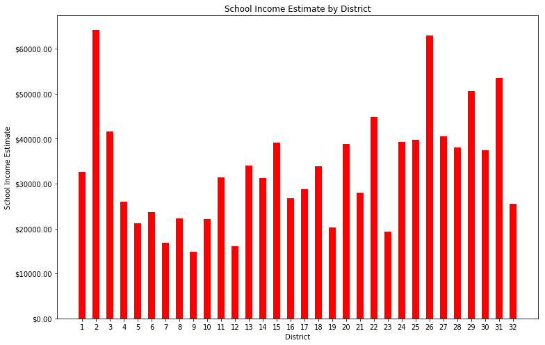

```python
data.dis_bargraph('School Income Estimate', dollarticks_y=True)
```

We can already see a disparity between districts and the average School Income Estimate. We can see that Districts 7, 9, 12, 19, and 23 seem to be in the lower-brackets. Let's see if there's a relationship between that and the proportion of students in those districts who get 4s on the SHSAT

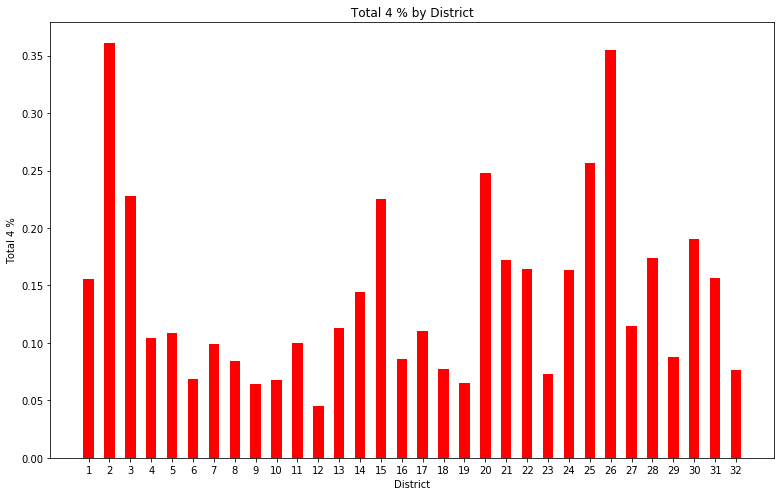

```python
data.dis_bargraph('Total 4 %')
```

The two richest districts 2 and 26 also have the highest proportion of 4s, suggesting a correlation between the two variables. Districts 6, 9, 10, 12, 18, 19, and 23 have the lowest performance on the SHSAT. Let's look at the relationship between proportion of 4s scored on the SHSAT and School Income.

For any data that I have grouped by like this data by District, the way I will add the information to the weighted formula is by converting the continuous data to a categorical bin that is automatically sorted into 'lowest, low, medium and high', merge that with the original dataset and give a score based on what bin that district landed in.

### Table of Weights

| Column | Lowest | Low | Medium | High |
| --- | --- | --- | --- | --- |
| School Income Estimate District Bin | 0.20 | 0.10 | -0.40 | -0.80 |
| Total 4 % District Bin | 0.30 | 0.15 | -0.40 | -0.80 |

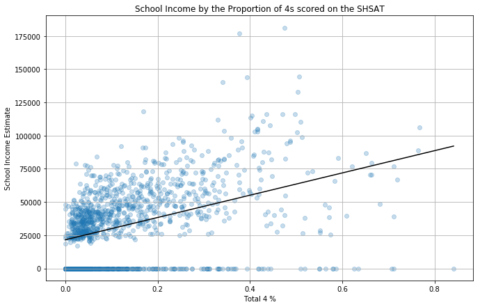

```python
data.simple_scatter(['Total 4 %', 'School Income Estimate'],
    title = "School Income by the Proportion of 4s scored on the SHSAT", reg_line=True)
```

Looking at just those two variables, Total 4 % and School Income Estimate do seem to have a positive correlation

### New Weights

| Column | Weight | Invert |
| --- | --- | --- |
| Total 4 % | 0.80 | True |
| School Income Estimate | 0.30 | True |

The **invert** flag determines if the column is inversely proportional to the In Need Score

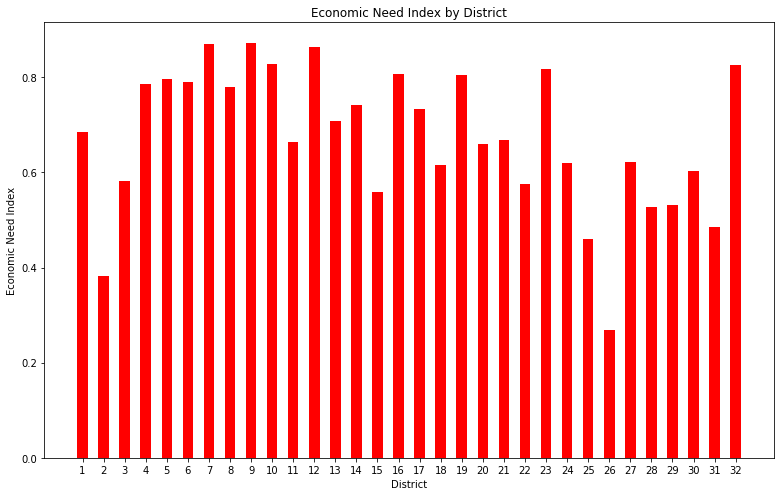

```python
data.dis_bargraph('Economic Need Index')
```

The two riches School districts have the lowest Economic Need Index (ENI) and there is some overlap between districts with high ENI and low Total 4 % scores.

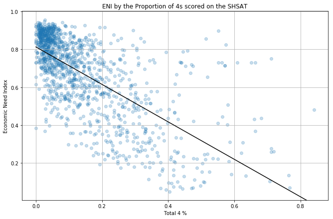

```python
data.simple_scatter(['Total 4 %', 'Economic Need Index'],
    title = "ENI by the Proportion of 4s scored on the SHSAT", reg_line=True)
```

There is a **strong correlation** between the ENI of a school and the proportion of 4s scored on an exam.

### New Weights

| Column | Weight | Invert |
| --- | --- | --- |
| Economic Need Index | 0.75 | False |

## Grades Offered By School

Each School offers a different range of Grades. Most focus on 3rd to 8th grade as those children take the SHSAT, but the schools also range from Special Education to Prekindergarten to all the way to 12th grade

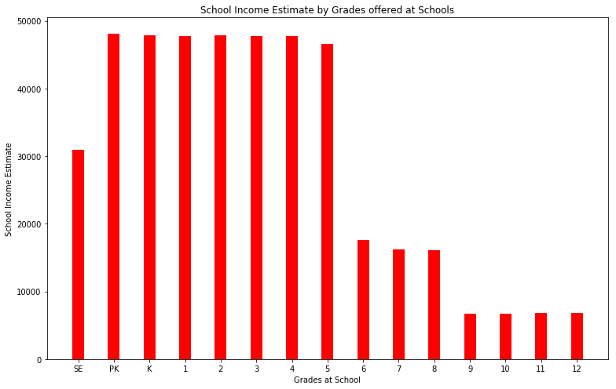

```python
data.grades_bargraph('School Income Estimate', title = 'School Income Estimate by Grades offered at Schools')
```

There is a **stark dropoff in funds** for schools that offer 6th grade and onwards. Special Education also has less income than the Prekindergarten to 5th grade Schools.

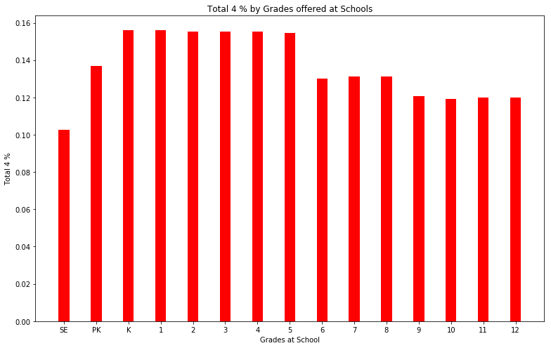

```python
data.grades_bargraph('Total 4 %', title = 'Total 4 % by Grades offered at Schools')
```

Schools that offer Special Education and 6th to 12th grade have a dropoff in proportion of 4s scored on the SHSAT.

### New Weights

If the school offers Special Education, or any grade through 6-12, add 0.5 to the In Need Score

## Trends by Grade

Each of the test scores on the SHSAT has been sorted by grade, so we can look at how the proportion of 4s scored on the Test is changed by the grade taking it

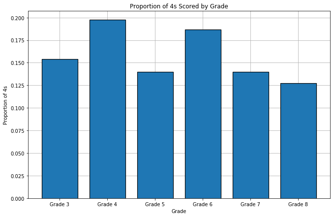

```python
data.sum_col_barplot(partial_cols = ['Grade 3 4s Total', 'Grade 4 4s Total',
    'Grade 5 4s Total','Grade 6 4s Total','Grade 7 4s Total',
    'Grade 8 4s Total'], names = ['Grade 3', 'Grade 4', 'Grade 5', 'Grade 6',
    'Grade 7', 'Grade 8'], title = 'Proportion of 4s Scored by Grade',
    xlabel = 'Grade', ylabel = 'Proportion of 4s',
    pos_gap = 40,
    prop_plot=True,
    cols=['Grade 3 4s Tested Total', 'Grade 4 4s Tested Total',
        'Grade 5 4s Tested Total','Grade 6 4s Tested Total',
        'Grade 7 4s Tested Total','Grade 8 4s Tested Total'])
```

It looks like, in general, students have an easier time with some grades than others in terms of the content on the SHSAT for that grade

We can also look at the proportion of 4s scored by subject.

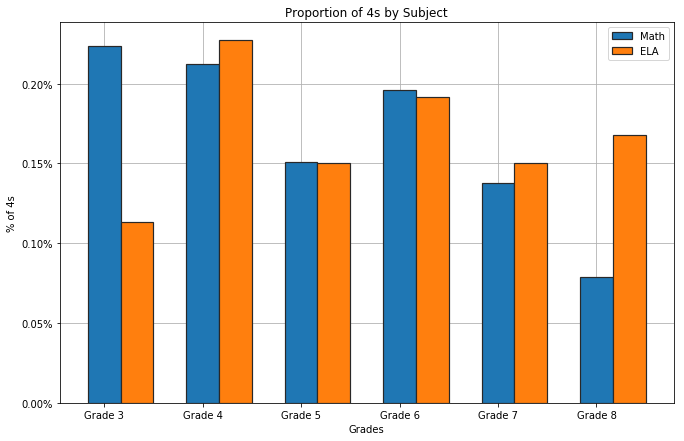

```python
cols = data.column_generator(subject = 'both')
data.two_shared_barplot(barWidth = 1,
                        col_1 = [i for i in cols if 'Math' in i],
                        col_2 = [i for i in cols if 'ELA' in i],
                        label_1 = 'Math',
                        label_2 = 'ELA',
                        section_labels = ['Grade 3', 'Grade 4', 'Grade 5',
                            'Grade 6', 'Grade 7', 'Grade 8'],
                        title = 'Proportion of 4s by Subject',
                        xlabel = 'Grades',
                        ylabel = '% of 4s')
```

This indicates that students in lower grades need more ELA education and students in higher grades need more Math education.

### New Weights

| Column | Weight | Invert |
| --- | --- | --- |
| Math Prop 4 | 0.80 | True |
| ELA Prop 4 | 0.80 | True |

## City

The City of each School is part of the dataset, let's explore which seem to be in the most need

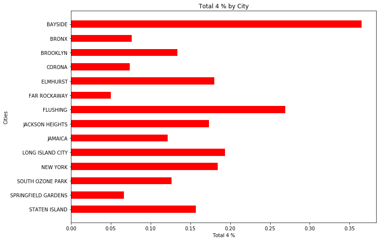

```python
data.city_bargraph('Total 4 %')
```

Bayside seems to be score much higher than other cities by a significant margin. The Bronx, Corona, Far Rockaway and Springfield Gardens all seem to be struggling on the SHSAT

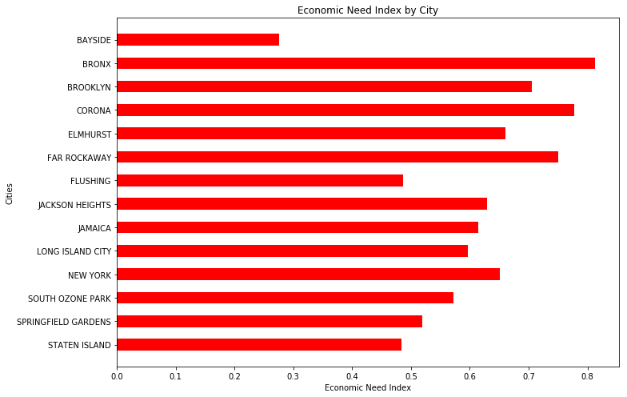

```python
data.city_bargraph('Economic Need Index')
```

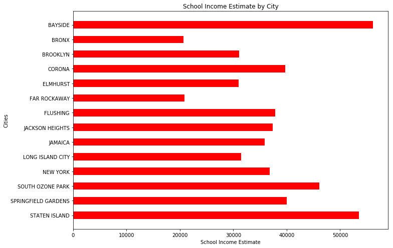

```python
data.city_bargraph('School Income Estimate')
```

### New Weights

| Column | Lowest | Low | Medium | High |
| --- | --- | --- | --- | --- |
| Total 4 % City Bin | 0.30 | 0.20 | -0.40 | -0.80 |
| School Income City Bin | 0.20 | 0.10 | -0.40 | -0.80 |
| ENI City Bin | 0.20 | 0.10 | -0.40 | -0.80 |

## Ethnicity

The school keeps tracks of the 4s scored on these exams and splits that data up by ethnicity. This means we can look at trends in Ethnicity based on those scores and other metrics.

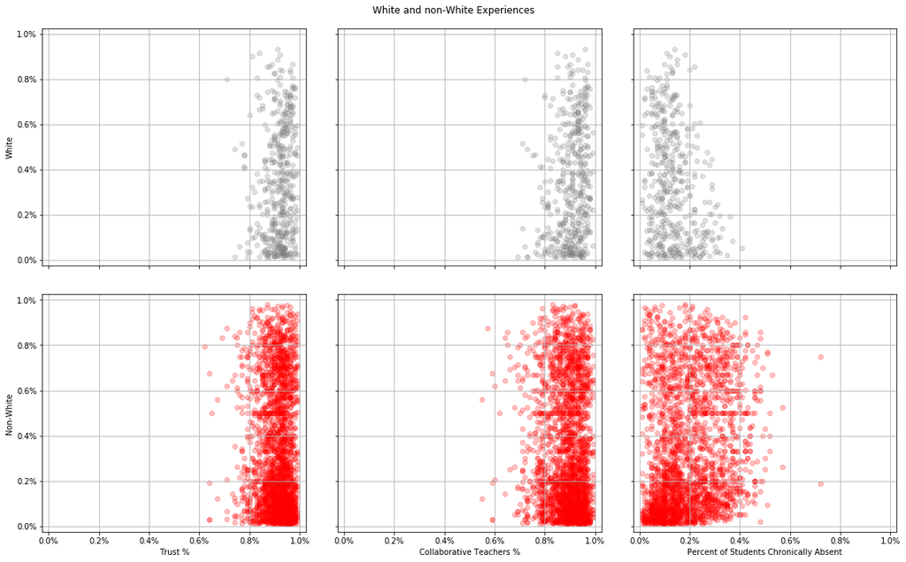

```python
non_white = ['Black Students %', 'Asian / Pacific Islanders Students %',
    'Hispanic / Latino Students %', 'American Indian / Alaska Native Students %',
    'Multiracial Students %']

graph_dict = {
    0:{ 'cols': ['Trust %', 'White Students %'], 'c': 'grey'},
    3:{ 'cols': ['Trust %', non_white], 'c': 'red'},
    1:{ 'cols': ['Collaborative Teachers %', 'White Students %'], 'c': 'grey'},
    4:{ 'cols': ['Collaborative Teachers %', non_white],'c': 'red'},
    2:{ 'cols': ['Percent of Students Chronically Absent', 'White Students %'],
        'c': 'grey'},
    5:{ 'cols': ['Percent of Students Chronically Absent', non_white],'c': 'red'}
}

data.multiplot_multicol(graph_dict, 2, 3, title="White and non-White Experiences",
    x_labels=['','','','Trust %', 'Collaborative Teachers %',
        'Percent of Students Chronically Absent'
             ],
    y_labels=['White', 'Non-White'
#               'White','Non-White'
             ],
    figwidth=16,
    figheight=10,
    graph_fun=Graph.scatter_two_percs,sharey=False,pair_cols=True,
    top=0.94, wspace=0.12, hspace=0.12)
```

For non-white students, which includes Black, Asian / Pacific Islanders, Hispanic / Latino, American Indian / Alaska Native and Multiracial students, every single scholastic metric is worse for them. There is less trust at schools, teachers are less collaborative, and students are more likely to be chronically absent

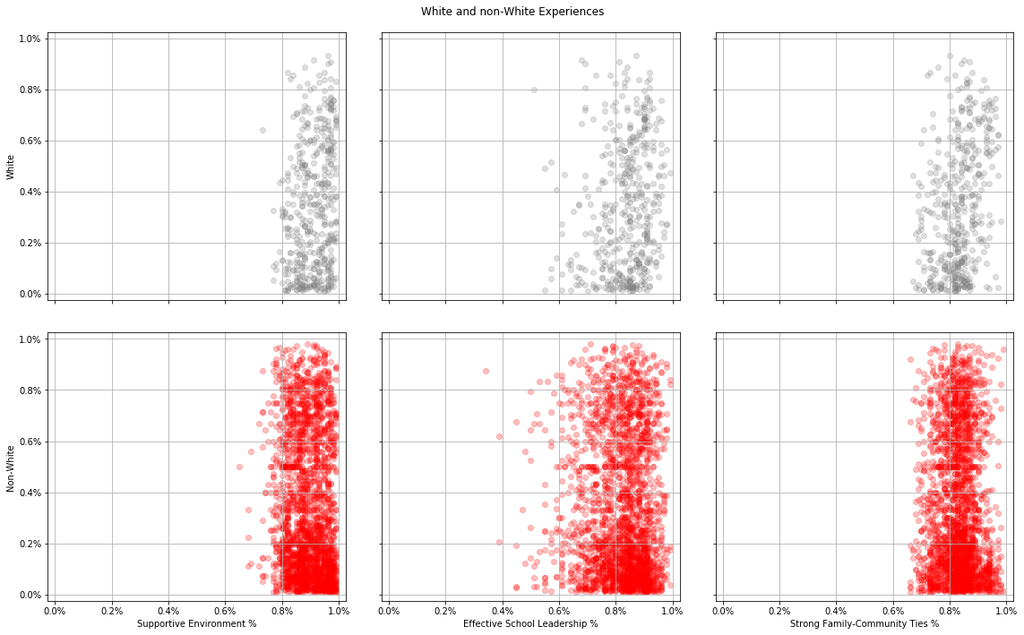

```python
graph_dict = {
    0:{ 'cols': ['Supportive Environment %', 'White Students %'], 'c': 'grey'},
    3:{ 'cols': ['Supportive Environment %', non_white], 'c': 'red'},
    1:{ 'cols': ['Effective School Leadership %', 'White Students %'], 'c': 'grey'},
    4:{ 'cols': ['Effective School Leadership %', non_white],'c': 'red'},
    2:{ 'cols': ['Strong Family-Community Ties %', 'White Students %'],
        'c': 'grey'},
    5:{ 'cols': ['Strong Family-Community Ties %', non_white],'c': 'red'}
}

data.multiplot_multicol(graph_dict, 2, 3, title="White and non-White Experiences",
    x_labels=['','','',
        'Supportive Environment %','Effective School Leadership %',
        'Strong Family-Community Ties %'],
    y_labels=['White', 'Non-White'],
    figwidth=16,
    figheight=10,
    graph_fun=Graph.scatter_two_percs,sharey=False,pair_cols=True,
    top=0.94, wspace=0.12, hspace=0.12)
```

Non-white students also have a less supportive environment and less effective school leadership. The Strong Family-Communitiy Ties seem to be pretty comparable

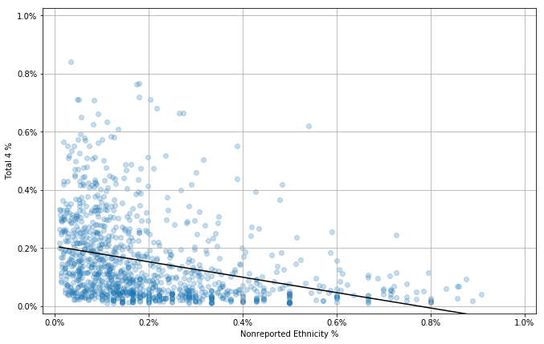

```python
data.scatter_two_percs(['Nonreported Ethnicity %', 'Total 4 %'], reg_line = True)
```

Schools that have not reported the ethnicity of students taking the SHSAT have a correlation with scoring less well on the SHSAT.

### New Weights

| Column | Weight | Invert |
| --- | --- | --- |
| White Students % | 0.80 | True |
| Black Students % | 0.80 | False |
| Economic Need Index | 0.75 | False |
| Hispanic / Latino Students % | 0.60 | False |
| Asian / Pacific Islanders Students % | 0.40 | False |
| Economically Disadvantaged Students % | 0.30 | False |
| American Indian / Alaska Native Students % | 0.15 | False |
| Nonreported Ethnicity % | 0.15 | False |
| Limited English Students % | 0.05 | False |
| Multiracial Students % | 0.05 | False |

## Targets

We just looked at the different Scholastic Ratings as how they pertain to ethnicity, but they are also broken down into categories:

- Exceeding Target
- Meeting Target
- Approaching Target
- Not Meeting Target

We can also compare how each of those relate to other measurements within the dataset.

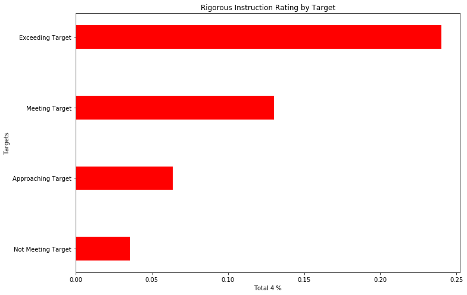

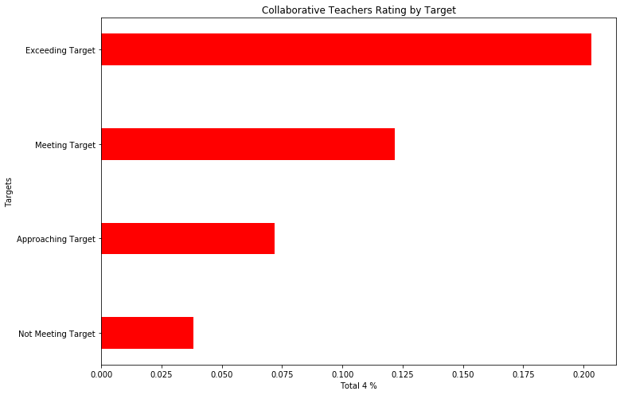

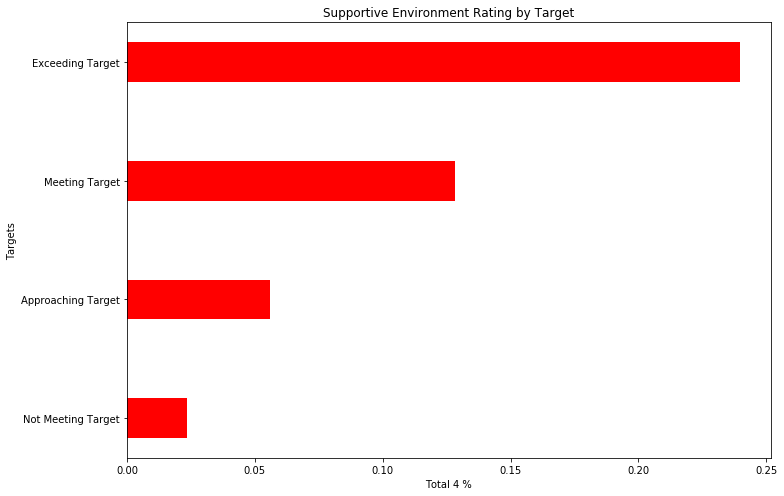

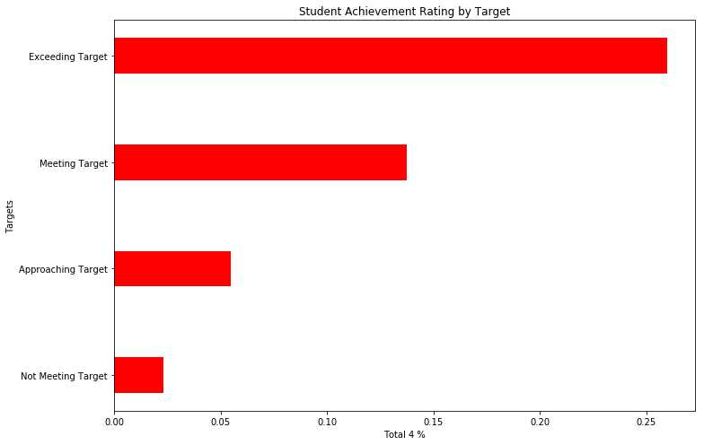

```python
ratings = ['Rigorous Instruction Rating', 'Collaborative Teachers Rating',
          'Supportive Environment Rating', 'Student Achievement Rating']

for rating in ratings:
    data.rating_barplot(rating, 'Total 4 %')
```

For the four Ratings above, Collaborative Teachers, Student Achievement, Supportive Environment, and Rigorous Instruction, all have a strong impact on the % of 4s scored by students.

### New Weights

| Column | Not Meeting Target | Approaching Target | Meeting Target | Exceeding Target |
| --- | --- | --- | --- | --- |
| Rigorous Instruction Rating | 0.75 | 0.55 | -0.75 | -1 |
| Collaborative Teachers Rating | 0.75 | 0.55 | -0.75 | -1 |
| Supportive Environment Rating | 0.75 | 0.55 | -0.75 | -1 |
| Effective School Leadership Rating | 0.5 | 0.25 | -0.25 | -.5 |
| Strong Family-Community Ties Rating | 0.25 | 0.10 | -0.10 | -0.25 |
| Trust Rating | 0.25 | 0.10 | -0.10 | -0.25 |
| Student Achievement Rating | 0.75 | 0.55 | -0.75 | -1 |

## Chronically Absent Students

Another piece of data within the dataset is concerning the Percentage of Students Chronically Absent

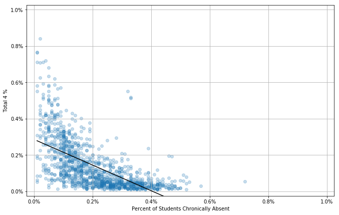

```python
data.scatter_two_percs(['Percent of Students Chronically Absent', 'Total 4 %'], reg_line = True)
```

There is definitely a correlation between students being Chronically Absent and not scoring well on the SHSAT

### New Weights

| Column | Weight | Invert |
| --- | --- | --- |
| Percent Of Students Chronically Absent | 0.25 | False |

## Number of Students

The only metric I have concerning the number of students at a school is the number of students there who had taken the SHSAT in the timeframe of the dataset.

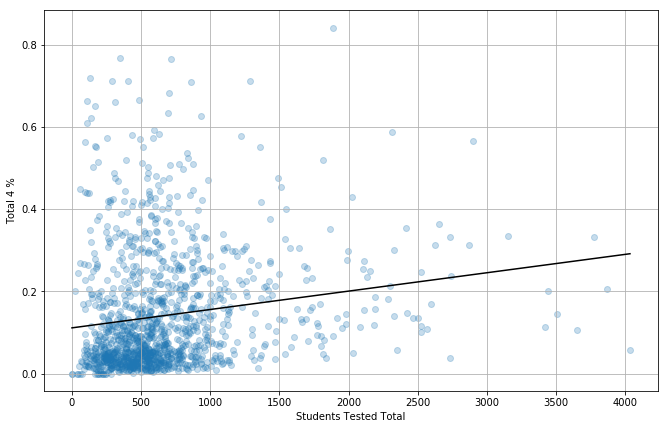

```python
data.simple_scatter(['Students Tested Total', 'Total 4 %'], reg_line = True)
```

There seems to be a weak correaltion between the number of students at a school and the score on the SHSAT

### New Weights

| Column | Weight | Invert |
| --- | --- | --- |
| Students Tested Total | 0.10 | True |

# Other Data About New York

Based on the open datasets provided by Kaggle about New York there were hundreds of datasets to choose from to see if there would be any correlation between the brought in data and the original data

## Grocery Stores

I wanted to see if any area in New York would correspond to a **food desert** so I found a dataset that contained a list of grocery stores within new york and counted the number of Grocery Stores available within that zip code. [This is the list of Grocery Stores in NYC](https://data.ny.gov/Economic-Development/Retail-Food-Stores/9a8c-vfzj)

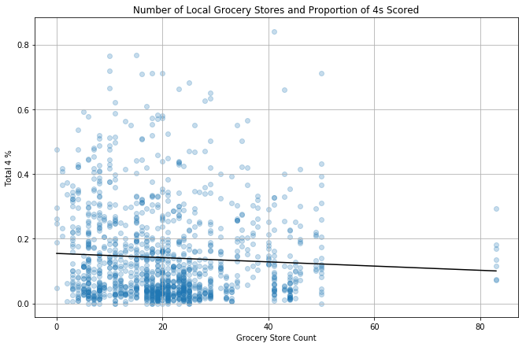

```python
data.simple_scatter(['Grocery Store Count', 'Total 4 %'], reg_line=True,
                   title = 'Number of Local Grocery Stores and Proportion of 4s Scored')
```

There was no correlation between the number of local grocery stores and the scores on the SHSAT.

## Public Transit

I was also curious about how the availability of public transit and if it affected scores on the SHSAT. [This is a list of Metro stations in NYC.](https://data.ny.gov/widgets/i9wp-a4ja). I took the co-ordinates for all the entrances to the stations and computed the shortest distance between a school and a station measured in miles.

This is a Euclidean Distance between a given school and the closest Metro station, so it's meant to be more of a measurement of how close to public transit the school is and not a measurement of travel distance

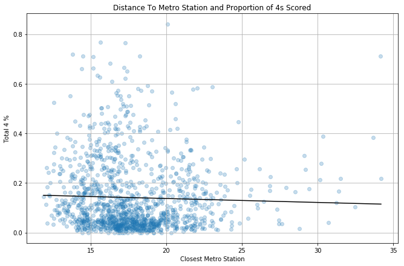

```python
data.simple_scatter(['Closest Metro Station', 'Total 4 %'], reg_line=True,
                   title = 'Distance To Metro Station and Proportion of 4s Scored')
```

Again, there was no correlation between the distance to the closest metro station and scoring on the SHSAT

## Car Safety

[This is a dataset about car crashes in NYC.](https://www.kaggle.com/new-york-city/nypd-motor-vehicle-collisions) I used this dataset as a measurement of how **safe** the roads are in NYC near these schools. Zip Codes were only tracked in this dataset if someone was injured in the car crash, meaning that these are only what can be considered moderate to severe car accidents.

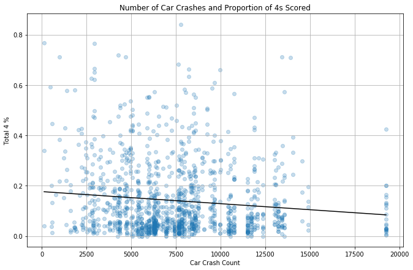

```python
data.simple_scatter(['Car Crash Count', 'Total 4 %'], reg_line=True,
                   title = 'Number of Car Crashes and Proportion of 4s Scored')
```

And again, there doesn't seem to be a correlation between Car Safety in areas around the Schools and scores on the SHSAT

This means that none of the merged in data has a strong enough correlation to be added to the In Need Scores weighted formula.

# Schools in Need

Now that all of our weights have been defined separately, let's put them together and see which schools are ranked as the most in need based on their 0-100 In Need Score

### Final Table of Weights

| Column | Not Meeting Target | Approaching Target | Meeting Target | Exceeding Target |
| --- | --- | --- | --- | --- |
| Rigorous Instruction Rating | 0.75 | 0.55 | -0.75 | -1 |
| Collaborative Teachers Rating | 0.75 | 0.55 | -0.75 | -1 |
| Supportive Environment Rating | 0.75 | 0.55 | -0.75 | -1 |
| Effective School Leadership Rating | 0.5 | 0.25 | -0.25 | -.5 |
| Strong Family-Community Ties Rating | 0.25 | 0.10 | -0.10 | -0.25 |
| Trust Rating | 0.25 | 0.10 | -0.10 | -0.25 |
| Student Achievement Rating | 0.75 | 0.55 | -0.75 | -1 |

| Column | Lowest | Low | Medium | High |
| --- | --- | --- | --- | --- |
| Total 4 % City Bin | 0.30 | 0.20 | -0.40 | -0.80 |
| School Income City Bin | 0.20 | 0.10 | -0.40 | -0.80 |
| ENI City Bin | 0.20 | 0.10 | -0.40 | -0.80 |
| School Income Estimate by District | 0.20 | 0.10 | -0.40 | -0.80 |
| Total 4 % by District | 0.30 | 0.15 | -0.40 | -0.80 |

[output not shown]

If the school offers Special Education, or any grade through 6-12, add 0.5 to the In Need Score

# Results

So by creating a weighted formula, we can look at the top 10 schools in need and various statistics about them.

```python
in_need_df['In Need Score'].describe()
```

```
count    1272.000000
mean       50.192210
std        19.366710
min         0.000000
25%        37.885988
50%        48.040560
75%        62.088627
max       100.000000
Name: In Need Score, dtype: float64
```

The values of In Need Score are pretty evenly split between 0 and a 100, meaning the weights I chose made the score not bee too skewed in either direction. The standard deviation is almost 20, which means the In Need Score also has a good variability. Both of these help me feel more confident in the weighted formula approach. This is *partly* due to me standardizing the data, but not *completely*. My first few tests with weights resulted in a skewed In Need Score.

```python
sum_df[other_cols]
```

|  | School Name | District | City | Economic Need Index | Percent of Students Chronically Absent | Economically Disadvantaged Students % | In Need Score |
| --- | --- | --- | --- | --- | --- | --- | --- |
| 790 | P.S. 306 ETHAN ALLEN | 19 | BROOKLYN | 0.875 | 0.57 | 0.684211 | 100.000000 |
| 158 | P.S. 123 MAHALIA JACKSON | 5 | NEW YORK | 0.835 | 0.49 | 0.300000 | 99.299490 |
| 287 | J.H.S. 123 JAMES M. KIERAN | 8 | BRONX | 0.876 | 0.28 | 0.583333 | 99.038918 |
| 305 | THE BRONX MATHEMATICS PREPARATORY SCHOOL | 8 | BRONX | 0.818 | 0.40 | 0.833333 | 98.247948 |
| 709 | EXPLORE EMPOWER CHARTER SCHOOL | 17 | BROOKLYN | 0.780 | 0.17 | 0.888889 | 97.148732 |
| 343 | I.S. 219 NEW VENTURE SCHOOL | 9 | BRONX | 0.929 | 0.35 | 0.000000 | 96.891761 |
| 359 | I.S. 339 | 9 | BRONX | 0.913 | 0.31 | 0.444444 | 96.630551 |
| 497 | P.S. 092 BRONX | 12 | BRONX | 0.923 | 0.42 | 0.500000 | 96.273333 |
| 813 | HYDE LEADERSHIP CHARTER SCHOOL- BROOKLYN | 19 | BROOKLYN | 0.801 | 0.25 | 0.947368 | 95.645013 |
| 782 | P.S. 202 ERNEST S. JENKYNS | 19 | BROOKLYN | 0.867 | 0.48 | 0.000000 | 95.490542 |

```python
sum_df[rating_cols]
```

|  | School Name | Students Tested Total | Collaborative Teachers % | Supportive Environment % | Effective School Leadership % | Strong Family-Community Ties % | Trust % | In Need Score |
| --- | --- | --- | --- | --- | --- | --- | --- | --- |
| 790 | P.S. 306 ETHAN ALLEN | 659 | 0.68 | 0.78 | 0.50 | 0.81 | 0.75 | 100.000000 |
| 158 | P.S. 123 MAHALIA JACKSON | 622 | 0.72 | 0.84 | 0.65 | 0.82 | 0.81 | 99.299490 |
| 287 | J.H.S. 123 JAMES M. KIERAN | 595 | 0.64 | 0.78 | 0.53 | 0.71 | 0.69 | 99.038918 |
| 305 | THE BRONX MATHEMATICS PREPARATORY SCHOOL | 451 | 0.75 | 0.79 | 0.65 | 0.76 | 0.81 | 98.247948 |
| 709 | EXPLORE EMPOWER CHARTER SCHOOL | 633 | 0.72 | 0.80 | 0.56 | 0.83 | 0.75 | 97.148732 |
| 343 | I.S. 219 NEW VENTURE SCHOOL | 561 | 0.66 | 0.81 | 0.63 | 0.70 | 0.79 | 96.891761 |
| 359 | I.S. 339 | 901 | 0.75 | 0.77 | 0.66 | 0.77 | 0.77 | 96.630551 |
| 497 | P.S. 092 BRONX | 371 | 0.78 | 0.81 | 0.65 | 0.85 | 0.85 | 96.273333 |
| 813 | HYDE LEADERSHIP CHARTER SCHOOL- BROOKLYN | 382 | 0.69 | 0.83 | 0.63 | 0.86 | 0.83 | 95.645013 |
| 782 | P.S. 202 ERNEST S. JENKYNS | 439 | 0.71 | 0.78 | 0.61 | 0.77 | 0.76 | 95.490542 |

```python
sum_df[score_cols]
```

|  | School Name | Total 4 % | Math Prop 4 | ELA Prop 4 | Average ELA Proficiency | Average Math Proficiency | In Need Score |
| --- | --- | --- | --- | --- | --- | --- | --- |
| 790 | P.S. 306 ETHAN ALLEN | 0.028832 | 0.021148 | 0.036585 | 2.12 | 2.04 | 100.000000 |
| 158 | P.S. 123 MAHALIA JACKSON | 0.016077 | 0.006309 | 0.026230 | 2.11 | 2.00 | 99.299490 |
| 287 | J.H.S. 123 JAMES M. KIERAN | 0.020168 | 0.022801 | 0.017361 | 2.15 | 1.98 | 99.038918 |
| 305 | THE BRONX MATHEMATICS PREPARATORY SCHOOL | 0.013304 | 0.013699 | 0.012931 | 2.17 | 2.01 | 98.247948 |
| 709 | EXPLORE EMPOWER CHARTER SCHOOL | 0.056872 | 0.059937 | 0.053797 | 2.28 | 2.37 | 97.148732 |
| 343 | I.S. 219 NEW VENTURE SCHOOL | 0.007130 | 0.003436 | 0.011111 | 1.98 | 1.92 | 96.891761 |
| 359 | I.S. 339 | 0.009989 | 0.004329 | 0.015945 | 2.05 | 2.04 | 96.630551 |
| 497 | P.S. 092 BRONX | 0.005391 | 0.005348 | 0.005435 | 2.00 | 1.90 | 96.273333 |
| 813 | HYDE LEADERSHIP CHARTER SCHOOL- BROOKLYN | 0.049738 | 0.052356 | 0.047120 | 2.40 | 2.48 | 95.645013 |
| 782 | P.S. 202 ERNEST S. JENKYNS | 0.015945 | 0.017937 | 0.013889 | 2.18 | 2.22 | 95.490542 |

```python
sum_df[eth_cols]
```

|  | School Name | White Students % | Asian / Pacific Islanders Students % | Black Students % | Hispanic / Latino Students % | American Indian / Alaska Native Students % | Multiracial Students % | Limited English Students % | Nonreported Ethnicity % | In Need Score |
| --- | --- | --- | --- | --- | --- | --- | --- | --- | --- | --- |
| 790 | P.S. 306 ETHAN ALLEN | 0.0 | 0.0 | 0.526316 | 0.263158 | 0.0 | 0.0 | 0.0 | 0.210526 | 100.000000 |
| 158 | P.S. 123 MAHALIA JACKSON | 0.0 | 0.0 | 0.700000 | 0.000000 | 0.0 | 0.0 | 0.0 | 0.300000 | 99.299490 |
| 287 | J.H.S. 123 JAMES M. KIERAN | 0.0 | 0.0 | 0.000000 | 0.833333 | 0.0 | 0.0 | 0.0 | 0.166667 | 99.038918 |
| 305 | THE BRONX MATHEMATICS PREPARATORY SCHOOL | 0.0 | 0.0 | 0.166667 | 0.500000 | 0.0 | 0.0 | 0.0 | 0.333333 | 98.247948 |
| 709 | EXPLORE EMPOWER CHARTER SCHOOL | 0.0 | 0.0 | 0.833333 | 0.000000 | 0.0 | 0.0 | 0.0 | 0.166667 | 97.148732 |
| 343 | I.S. 219 NEW VENTURE SCHOOL | 0.0 | 0.0 | 0.250000 | 0.750000 | 0.0 | 0.0 | 0.0 | 0.000000 | 96.891761 |
| 359 | I.S. 339 | 0.0 | 0.0 | 0.111111 | 0.777778 | 0.0 | 0.0 | 0.0 | 0.111111 | 96.630551 |
| 497 | P.S. 092 BRONX | 0.0 | 0.0 | 0.000000 | 1.000000 | 0.0 | 0.0 | 0.0 | 0.000000 | 96.273333 |
| 813 | HYDE LEADERSHIP CHARTER SCHOOL- BROOKLYN | 0.0 | 0.0 | 0.789474 | 0.052632 | 0.0 | 0.0 | 0.0 | 0.157895 | 95.645013 |
| 782 | P.S. 202 ERNEST S. JENKYNS | 0.0 | 0.0 | 0.857143 | 0.000000 | 0.0 | 0.0 | 0.0 | 0.142857 | 95.490542 |

# Conclusion

Looking at all the possible variables of the dataset with 1272 different Schools I created a weighted formula to score Schools based on different factors correlated with the scores on the SHSAT. I decided on these weights based on how much I determined they would affect the scores on the SHSAT, but I believe in the method that I used for determining the score.

What I belive could have helped me in the accuracy of assigning weights to different variables would be more domain knowledge about the subject. I have never worked in education before and it's possible that I could have made wrong assumptions about the strength of correlations given the dataset and any inherit biases that may have been within the data collected.

Things I would have liked to explore if time wasn't a factor:

- A description for each school describing how their score was calculated, as in, which weighted scores scored the highest and lowest
- Other types of visualization
- More efficient methods in Classes that I wrote. Many solutions were not optimized beyond the sake of organization into smaller functions. I know many for loops could be replaced with vectorized solutions using Numpy Arrays for greater efficiencies.
- More research into the values I chose for the weighted function